# f6575730-d902-46ad-9c6c-3526ab6c1d28

**Review**

Hi, Mohamad! I'm happy to review your project today.

You can find my comments in colored markdown cells:

If everything is done successfully.

If I have some (optional) suggestions, or questions to think about, or general comments.

If a section requires some corrections. Work can't be accepted with red comments.

Please don't remove my comments, as it will make further review iterations much harder for me.

Feel free to reply to my comments or ask questions using the following template:

For your comments and questions.

First of all, thank you for turning in the project! You did an excellent job! The project is accepted. Good luck on the next sprint!

# Zuber

### The aim of this project is to understand passenger preferences and the impact of external factors on rides in order to assist Zuber, a new ride-sharing company in analyzing the transportation data of Chicago. This will help them understand their competitors and how to beat this competition.

```python
# Libraries

import pandas as pd
import matplotlib.pyplot as plt
import seaborn as sns
import plotly.graph_objects as go
import plotly.express as px
import scipy.stats as stats
import statsmodels.api as sm
from scipy.stats import ttest_ind
from scipy.stats import pearsonr
import numpy as np
import datetime
```

```python
# Laoding CSV Files

df_company_trips = pd.read_csv("/datasets/project_sql_result_01.csv")
```

### The above dataframe is for the Company Trips data.

```python
# Loading CSV Files

df_dropoff_neighborhoods = pd.read_csv("/datasets/project_sql_result_04.csv")
```

### The above dataframe is for the Dropoff Neighborhoods data.

```python
# Load CSV Files

df_rides = pd.read_csv("/datasets/project_sql_result_07.csv")
```

### The above dataframe contains data on rides from the Loop to O'Hare International Airport.

```python
# working code

df_company_trips.info()
```

```
<class 'pandas.core.frame.DataFrame'>
RangeIndex: 64 entries, 0 to 63
Data columns (total 2 columns):
 #   Column        Non-Null Count  Dtype
---  ------        --------------  -----
 0   company_name  64 non-null     object
 1   trips_amount  64 non-null     int64
dtypes: int64(1), object(1)
memory usage: 1.1+ KB
```

```python
# working code

df_dropoff_neighborhoods.info()
```

```
<class 'pandas.core.frame.DataFrame'>
RangeIndex: 94 entries, 0 to 93
Data columns (total 2 columns):
 #   Column                 Non-Null Count  Dtype
---  ------                 --------------  -----
 0   dropoff_location_name  94 non-null     object
 1   average_trips          94 non-null     float64
dtypes: float64(1), object(1)
memory usage: 1.6+ KB
```

```python
# working code

df_rides.info()
```

```
<class 'pandas.core.frame.DataFrame'>
RangeIndex: 1068 entries, 0 to 1067
Data columns (total 3 columns):
 #   Column              Non-Null Count  Dtype
---  ------              --------------  -----
 0   start_ts            1068 non-null   object
 1   weather_conditions  1068 non-null   object
 2   duration_seconds    1068 non-null   float64
dtypes: float64(1), object(2)
memory usage: 25.2+ KB
```

```python
# working code

df_company_trips.dtypes
```

```
company_name    object
trips_amount     int64
dtype: object
```

```python
# working code

df_dropoff_neighborhoods.dtypes
```

```
dropoff_location_name     object
average_trips            float64
dtype: object
```

```python
# working code

df_rides.dtypes
```

```
start_ts               object
weather_conditions     object
duration_seconds      float64
dtype: object
```

```python
# working code

df_company_trips.describe()
```

|  | trips_amount |
| --- | --- |
| count | 64.000000 |
| mean | 2145.484375 |
| std | 3812.310186 |
| min | 2.000000 |
| 25% | 20.750000 |
| 50% | 178.500000 |
| 75% | 2106.500000 |
| max | 19558.000000 |

```python
# working code

df_dropoff_neighborhoods.describe()
```

|  | average_trips |
| --- | --- |
| count | 94.000000 |
| mean | 599.953728 |
| std | 1714.591098 |
| min | 1.800000 |
| 25% | 14.266667 |
| 50% | 52.016667 |
| 75% | 298.858333 |
| max | 10727.466667 |

```python
# working code

df_rides.describe()
```

|  | duration_seconds |
| --- | --- |
| count | 1068.000000 |
| mean | 2071.731273 |
| std | 769.461125 |
| min | 0.000000 |
| 25% | 1438.250000 |
| 50% | 1980.000000 |
| 75% | 2580.000000 |
| max | 7440.000000 |

```python
# Prepare Data

# Convert missing values to NaN
df_company_trips = df_company_trips.replace("", np.nan)
```

### Missing values are converted to NaN to make it more convenient to analyze the data.

```python
# Prepare Data

# Convert missing values to NaN
df_dropoff_neighborhoods = df_dropoff_neighborhoods.replace("", np.nan)
```

### Missing values are converted to NaN to make it more convenient to analyze the data.

```python
# Prepare Data

# Convert missing values to NaN
df_rides = df_rides.replace("", np.nan)
```

### Missing values are converted to NaN to make it more convenient to analyze the data.

```python
# Prepare Data

# Drop duplicate rows

df_company_trips = df_company_trips.drop_duplicates()
```

### Company Trips dataframe is clear from duplicates

```python
# Prepare Data

# Drop duplicate rows

df_dropoff_neighborhoods = df_dropoff_neighborhoods.drop_duplicates()
```

### Dropoff Neighborhoods dataframe is clear from duplicates.

```python
df_rides = df_rides.drop_duplicates()
```

### Rides dataframe is clear from duplicates

```python
df_company_trips.head()
```

|  | company_name | trips_amount |
| --- | --- | --- |
| 0 | Flash Cab | 19558 |
| 1 | Taxi Affiliation Services | 11422 |
| 2 | Medallion Leasing | 10367 |
| 3 | Yellow Cab | 9888 |
| 4 | Taxi Affiliation Service Yellow | 9299 |

```python
df_dropoff_neighborhoods.head()
```

|  | dropoff_location_name | average_trips |
| --- | --- | --- |
| 0 | Loop | 10727.466667 |
| 1 | River North | 9523.666667 |
| 2 | Streeterville | 6664.666667 |
| 3 | West Loop | 5163.666667 |
| 4 | O'Hare | 2546.900000 |

```python
df_rides.head()
```

|  | start_ts | weather_conditions | duration_seconds |
| --- | --- | --- | --- |
| 0 | 2017-11-25 16:00:00 | Good | 2410.0 |
| 1 | 2017-11-25 14:00:00 | Good | 1920.0 |
| 2 | 2017-11-25 12:00:00 | Good | 1543.0 |
| 3 | 2017-11-04 10:00:00 | Good | 2512.0 |
| 4 | 2017-11-11 07:00:00 | Good | 1440.0 |

**Reviewer's comment**

The data was loaded and inspected

```python
# Top 10 neighborhoods in terms of dropoffs

df_top_neighborhoods = df_dropoff_neighborhoods.sort_values(by='average_trips', ascending=False)

# Select the top 10 neighborhoods
top_10_neighborhoods = df_top_neighborhoods.head(10)

# Print
print(top_10_neighborhoods)
```

```
  dropoff_location_name  average_trips
0                  Loop   10727.466667
1           River North    9523.666667
2         Streeterville    6664.666667
3             West Loop    5163.666667
4                O'Hare    2546.900000
5             Lake View    2420.966667
6            Grant Park    2068.533333
7         Museum Campus    1510.000000
8            Gold Coast    1364.233333
9    Sheffield & DePaul    1259.766667
```

### Top 10 Neighborhoods in Terms of Drop-offs are: Loop, River North, Streeterville, West Loop, O'Hare, Lake View, Grant Park, Museum Campus, Gold Coast, Sheffield & DePaul.

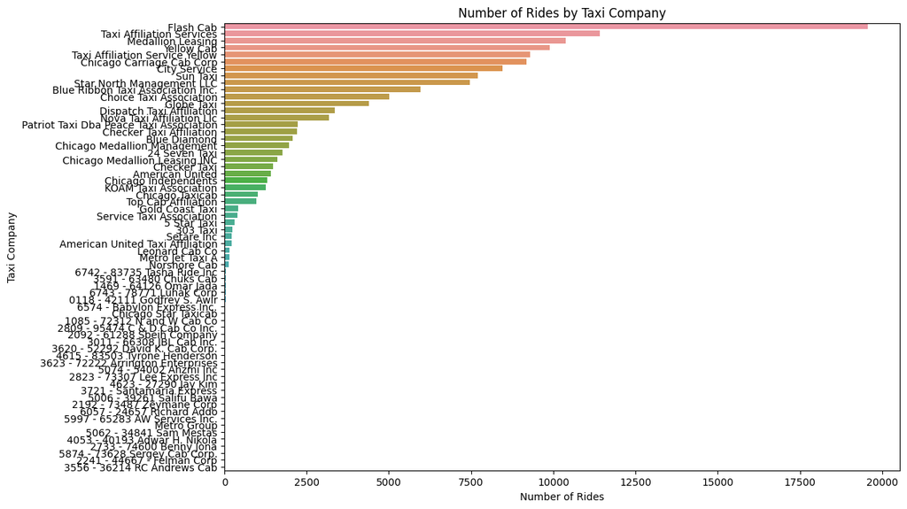

```python
# Data Visualization

# Sort the data by number of rides in descending order
df_company_trips_sorted = df_company_trips.sort_values(by='trips_amount', ascending=False)

# Plotting the bar plot
plt.figure(figsize=(12, 8))
sns.barplot(x='trips_amount', y='company_name', data=df_company_trips_sorted)
plt.title('Number of Rides by Taxi Company')
plt.xlabel('Number of Rides')
plt.ylabel('Taxi Company')
plt.show()
```

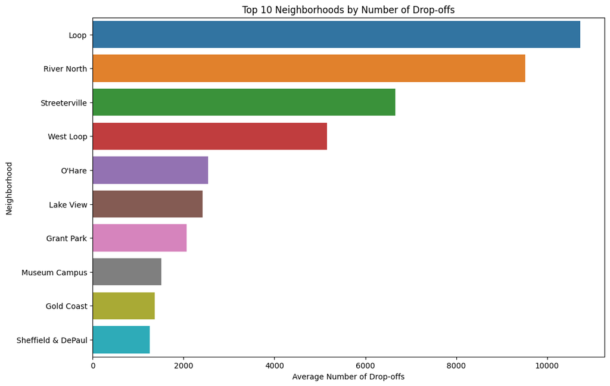

```python
# Data Visualization

# Sort the data by average number of trips in descending order
df_top_neighborhoods = df_dropoff_neighborhoods.sort_values(by='average_trips', ascending=False).head(10)

# Plotting the bar plot
plt.figure(figsize=(12, 8))
sns.barplot(x='average_trips', y='dropoff_location_name', data=df_top_neighborhoods)
plt.title('Top 10 Neighborhoods by Number of Drop-offs')
plt.xlabel('Average Number of Drop-offs')
plt.ylabel('Neighborhood')
plt.show()
```

**Reviewer's comment**

Top taxi companies and dropoff locations were identified successfully!

```python
# Testing Hypothesis

# Separate the data into two groups: rainy Saturdays and non-rainy Saturdays
rainy_saturdays = df_rides[df_rides['weather_conditions'] == 'Bad']['duration_seconds']
non_rainy_saturdays = df_rides[df_rides['weather_conditions'] == 'Good']['duration_seconds']
```

```python
# Testing Hypothesis

# Perform a two-sample t-test
t_statistic, p_value = ttest_ind(rainy_saturdays, non_rainy_saturdays)

# Significance level
alpha = 0.05

# Print the results
print("T-Statistic:", t_statistic)
print("P-Value:", p_value)

# Compare the p-value with the significance level
if p_value < alpha:
    print("Reject the null hypothesis. There is sufficient evidence to conclude that the average duration of rides from the Loop to O'Hare International Airport changes on rainy Saturdays.")
else:
    print("Fail to reject the null hypothesis. There is not enough evidence to conclude that the average duration of rides from the Loop to O'Hare International Airport changes on rainy Saturdays.")
```

```
T-Statistic: 5.427957689754561
P-Value: 7.397770692813658e-08
Reject the null hypothesis. There is sufficient evidence to conclude that the average duration of rides from the Loop to O'Hare International Airport changes on rainy Saturdays.
```

**Reviewer's comment**

The test was conducted correctly, conclusion is constistent with test results

### The P-value comes out to be 7.397770692813658e-08 which is far less than 0.05 the valye of alpha.

### This means that we reject the null hypothesis, there is sufficient evidence to conclude that the average duration of rides from Loop neighborhoods to O'Hare International Airport changes on rainy Saturdays.

**Reviewer's comment**

Makes sense!

# Conclusion

### There is sufficient evidence to conclude that the average duration of rides from Loop neighborhoods to O'Hare International Airport changes on rainy Saturdays.

### In order to beat the competition, Zuber needs to make sure the passengers are transported in less duration than other taxi companies.

### Zuber should focues on the Top 10 neighboords in terms of Drop-offs to increase it's demand.

### Zuber have to provide better customer experience to distinguish itself in the market.

### Zuber's biggest competitor is Flash Cab, there is a real need to attract it's customers by building a loyalty program based on points for ride-shares, for example.

**Reviewer's comment**

Nice summary!